# Module 03: Measurement — Exploratory and Confirmatory Factor Analysis

## 5.4 Reading the lavaan Output — Complete Section-by-Section Guide

The `summary()` output is long and contains many sections. Here is what each one means and how to read it:

Complete Section-by-Section Guide to lavaan CFA Output

| Section | What It Means |
| --- | --- |
| lavaan version + Number of observations | Confirms the sample size. Always verify this matches your expected N after listwise deletion. |
| Estimator | MLR = Maximum Likelihood with robust SEs. Use MLR for non-normal data (ordinal items). Use ML for multivariate normal data. |
| Optimization method | NLMINB is the default optimizer. You do not need to change this. |
| Number of model parameters | The number of free parameters estimated. More parameters = more complex model. |
| Model Test User Model | The overall model chi-squared test |
| Test statistic (χ²) | How different the model-implied covariance matrix is from the observed one. Scaled by N. Almost always significant with large samples. |
| Degrees of freedom | Degrees of freedom = (p*(p+1)/2) − free parameters, where p = number of items. More df = more constrained model. |
| P-value | With N > 500, this is almost always < .05 even for good models. Focus on fit indices instead. |
| Model Test Baseline Model | The null model assumes all items are uncorrelated. CFI and TLI are computed relative to this null. |
| User Model vs. Baseline Model (CFI, TLI) | CFI: proportion of covariance explained vs. null. TLI: similar but penalises complexity. Both should be ≥ .95 for good fit. |
| Root Mean Square Error (RMSEA + CI) | RMSEA: average discrepancy per df. ≤ .06 = good, ≤ .08 = acceptable. The 90% CI should not include values > .10. |
| Standardized Root Mean Square Residual (SRMR) | Average absolute difference between model-implied and observed correlations. ≤ .08 = good fit. |
| Parameter Estimates: Latent Variables (=~) | This is the core output: estimated factor loadings |
| Estimate column | The unstandardised loading in the metric of the item (raw score units). Interpretation depends on scale. |
| Std.Err column | Standard error of the estimate. Smaller = more precise. |
| z-value column | Estimate / Std.Err. Used to compute p-value. \|z\| > 1.96 = p < .05. |
| P(>\|z\|) column | Two-tailed p-value testing H₀: this parameter = 0. Almost all loadings will be significant in a correctly specified model. |
| ci.lower / ci.upper columns | 95% confidence interval. Does it include zero? If yes, the loading is not significant. |
| Std.lv column | Loading standardised with respect to latent variable variance only. Useful if std.lv=FALSE. |
| Std.all column | FULLY STANDARDISED LOADING: this is what you report in papers. Correlation between item and factor. Range: −1 to +1. > \|.40\| = acceptable; > \|.60\| = good; > \|.80\| = excellent. |
| Parameter Estimates: Covariances () | Factor covariances (or correlations if std.lv=TRUE). A covariance of .35 between Agreeableness and Conscientiousness means people high in one tend to be high in the other. |
| Parameter Estimates: Variances | Residual variance estimates for each item and each latent variable |
| Residual variances (for observed items) | Residual (unique) variance for each item — the portion NOT explained by its factor. 1 − Std.all² = residual proportion. |
| Variance of latent variables | If std.lv=TRUE, latent variances are fixed to 1.0 and will not appear as free parameters. |

## 5.5 Extracting and Displaying the Key Results

```r
# Extract standardised loadings for clean reporting
loadings_tbl <- parameterEstimates(cfa_fit, standardized=TRUE) |>
  filter(op == "=~") |>      # keep only factor loading parameters
  dplyr::select(lhs, rhs, std.all, se, pvalue, ci.lower, ci.upper) |>
  mutate(
    std.all  = round(std.all, 3),
    se       = round(se, 3),
    pvalue   = ifelse(pvalue < .001, "< .001", round(pvalue, 3)),
    ci.lower = round(ci.lower, 3),
    ci.upper = round(ci.upper, 3),
    # Communality from standardised loading: h2 = lambda^2
    h2       = round(std.all^2, 3),
    Quality  = case_when(
      abs(std.all) >= 0.70 ~ "Strong",
      abs(std.all) >= 0.50 ~ "Acceptable",
      abs(std.all) >= 0.30 ~ "Marginal",
      TRUE                 ~ "Weak — review"
    )
  ) |>
  rename(Factor=lhs, Item=rhs, `λ (std.)`=std.all, SE=se, p=pvalue,
         `CI low`=ci.lower, `CI high`=ci.upper, `h²`=h2)

kbl(loadings_tbl,
    caption="CFA Standardised Factor Loadings — Big Five Model") |>
  kable_styling(bootstrap_options=c("striped","hover","condensed")) |>
  group_rows("Agreeableness", 1, 5) |>
  group_rows("Conscientiousness", 6, 10) |>
  group_rows("Extraversion", 11, 15) |>
  group_rows("Neuroticism", 16, 20) |>
  group_rows("Openness", 21, 25) |>
  column_spec(8, color=ifelse(loadings_tbl$Quality %in% c("Weak — review","Marginal"),
                               "#C0392B","#27AE60"))
```

CFA Standardised Factor Loadings — Big Five Model

| Factor | Item | λ (std.) | SE | p | CI low | CI high | h² | Quality |
| --- | --- | --- | --- | --- | --- | --- | --- | --- |
| **Agreeableness** |  |  |  |  |  |  |  |  |
| Agreeableness | A1 | 0.344 | 0.035 | < .001 | 0.416 | 0.552 | 0.118 | Marginal |
| Agreeableness | A2 | -0.648 | 0.028 | < .001 | -0.820 | -0.709 | 0.420 | Acceptable |
| Agreeableness | A3 | -0.749 | 0.029 | < .001 | -1.039 | -0.926 | 0.561 | Strong |
| Agreeableness | A4 | -0.510 | 0.033 | < .001 | -0.823 | -0.692 | 0.260 | Acceptable |
| Agreeableness | A5 | -0.687 | 0.028 | < .001 | -0.928 | -0.819 | 0.472 | Acceptable |
| **Conscientiousness** |  |  |  |  |  |  |  |  |
| Conscientiousness | C1 | 0.551 | 0.034 | < .001 | 0.614 | 0.747 | 0.304 | Acceptable |
| Conscientiousness | C2 | 0.592 | 0.035 | < .001 | 0.712 | 0.849 | 0.350 | Acceptable |
| Conscientiousness | C3 | 0.546 | 0.030 | < .001 | 0.646 | 0.763 | 0.298 | Acceptable |
| Conscientiousness | C4 | -0.702 | 0.030 | < .001 | -1.026 | -0.908 | 0.493 | Strong |
| Conscientiousness | C5 | -0.620 | 0.036 | < .001 | -1.083 | -0.942 | 0.384 | Acceptable |
| **Extraversion** |  |  |  |  |  |  |  |  |
| Extraversion | E1 | 0.564 | 0.035 | < .001 | 0.852 | 0.988 | 0.318 | Acceptable |
| Extraversion | E2 | 0.699 | 0.031 | < .001 | 1.066 | 1.189 | 0.489 | Acceptable |
| Extraversion | E3 | -0.627 | 0.030 | < .001 | -0.907 | -0.788 | 0.393 | Acceptable |
| Extraversion | E4 | -0.703 | 0.030 | < .001 | -1.091 | -0.972 | 0.494 | Strong |
| Extraversion | E5 | -0.553 | 0.032 | < .001 | -0.805 | -0.681 | 0.306 | Acceptable |
| **Neuroticism** |  |  |  |  |  |  |  |  |
| Neuroticism | N1 | 0.825 | 0.027 | < .001 | 1.248 | 1.352 | 0.681 | Strong |
| Neuroticism | N2 | 0.803 | 0.026 | < .001 | 1.179 | 1.282 | 0.645 | Strong |
| Neuroticism | N3 | 0.721 | 0.029 | < .001 | 1.093 | 1.205 | 0.520 | Strong |
| Neuroticism | N4 | 0.573 | 0.036 | < .001 | 0.829 | 0.969 | 0.328 | Acceptable |
| Neuroticism | N5 | 0.503 | 0.036 | < .001 | 0.746 | 0.886 | 0.253 | Acceptable |
| **Openness** |  |  |  |  |  |  |  |  |
| Openness | O1 | 0.564 | 0.029 | < .001 | 0.579 | 0.692 | 0.318 | Acceptable |
| Openness | O2 | -0.418 | 0.046 | < .001 | -0.739 | -0.558 | 0.175 | Marginal |
| Openness | O3 | 0.724 | 0.035 | < .001 | 0.803 | 0.941 | 0.524 | Strong |
| Openness | O4 | 0.233 | 0.033 | < .001 | 0.212 | 0.343 | 0.054 | Weak — review |
| Openness | O5 | -0.461 | 0.039 | < .001 | -0.685 | -0.534 | 0.213 | Marginal |

**Reading this table:**

- **λ (std.):** The standardised loading. This is the number you report in your methods section. A loading of .65 means the item correlates .65 with its factor.
- **h²:** Communality = λ². An h² of .42 means 42% of this item’s variance is shared with its factor; 58% is unique. Items with h² < .20 are barely measuring the factor.
- **Quality column:** Benchmark guidance. A scale with mostly “Acceptable” and “Strong” items is well-specified. Several “Weak” items suggest the items need revision or the model needs rethinking.
- **p column:** Almost every loading will be significant — this is just telling you the loading is not zero. The magnitude (λ) and communality (h²) are more informative than the p-value here.

## 5.6 Evaluating Model Fit

```r
fit_indices <- fitMeasures(cfa_fit,
  c("chisq","df","pvalue","cfi","tli","rmsea","rmsea.ci.lower",
    "rmsea.ci.upper","rmsea.pvalue","srmr","aic","bic")) |>
  round(3)

tibble(
  Index   = c("χ² (chi-squared)","df","p(χ²)","CFI","TLI",
               "RMSEA","RMSEA 95% CI lower","RMSEA 95% CI upper",
               "p(RMSEA ≤ .05)","SRMR","AIC","BIC"),
  Value   = fit_indices,
  Benchmark = c("—","—","> .05 for exact fit",
                "≥ .95 good, ≥ .90 acceptable",
                "≥ .95 good, ≥ .90 acceptable",
                "≤ .06 good, ≤ .08 acceptable",
                "—","—",">.05 = close fit",
                "≤ .08 good, ≤ .10 acceptable",
                "Lower = better","Lower = better"),
  Verdict = c(
    "Ignore significance with N > 300",
    "More df = more constrained (parsimonious) model",
    if(fit_indices["pvalue"] > .05) "✓ Not significant — exact fit" else "✗ Significant (expected at large N)",
    if(fit_indices["cfi"] >= .95) "✓ Good" else if(fit_indices["cfi"] >= .90) "~ Acceptable" else "✗ Poor",
    if(fit_indices["tli"] >= .95) "✓ Good" else if(fit_indices["tli"] >= .90) "~ Acceptable" else "✗ Poor",
    if(fit_indices["rmsea"] <= .06) "✓ Good" else if(fit_indices["rmsea"] <= .08) "~ Acceptable" else "✗ Poor",
    "—","—",
    if(fit_indices["rmsea.pvalue"] > .05) "✓ Close fit confirmed" else "~ Not close fit",
    if(fit_indices["srmr"] <= .08) "✓ Good" else if(fit_indices["srmr"] <= .10) "~ Acceptable" else "✗ Poor",
    "Use for model comparison only","Use for model comparison only"
  )
) |>
  kbl(caption="CFA Fit Index Summary — Big Five Model",
      col.names=c("Index","Value","Benchmark","Verdict")) |>
  kable_styling(bootstrap_options=c("striped","hover")) |>
  row_spec(c(4,5), background="#EBF5FB") |>
  row_spec(6, background="#EAFAF1") |>
  row_spec(10, background="#FEF9E7") |>
  footnote(general=paste(
    "CFI and TLI compare your model to a null model where all items are uncorrelated.",
    "\nRMSEA measures the average discrepancy per degree of freedom.",
    "\nSRMR is the average absolute difference between model-implied and observed correlations."
  ))
```

CFA Fit Index Summary — Big Five Model

| Index | Value | Benchmark | Verdict |
| --- | --- | --- | --- |
| χ² (chi-squared) | 4165.467 | — | Ignore significance with N > 300 |
| df | 265.000 | — | More df = more constrained (parsimonious) model |
| p(χ²) | 0.000 | > .05 for exact fit | ✗ Significant (expected at large N) |
| CFI | 0.782 | ≥ .95 good, ≥ .90 acceptable | ✗ Poor |
| TLI | 0.754 | ≥ .95 good, ≥ .90 acceptable | ✗ Poor |
| RMSEA | 0.078 | ≤ .06 good, ≤ .08 acceptable | ~ Acceptable |
| RMSEA 95% CI lower | 0.076 | — | — |
| RMSEA 95% CI upper | 0.080 | — | — |
| p(RMSEA ≤ .05) | 0.000 | >.05 = close fit | ~ Not close fit |
| SRMR | 0.075 | ≤ .08 good, ≤ .10 acceptable | ✓ Good |
| AIC | 199800.476 | Lower = better | Use for model comparison only |
| BIC | 200148.363 | Lower = better | Use for model comparison only |

Note:  
CFI and TLI compare your model to a null model where all items are uncorrelated. RMSEA measures the average discrepancy per degree of freedom. SRMR is the average absolute difference between model-implied and observed correlations.

## 5.7 Factor Correlations

```r
# Extract factor covariances/correlations from the model
# With std.lv=TRUE, these ARE correlations (variances fixed to 1)
factor_cors <- parameterEstimates(cfa_fit, standardized=TRUE) |>
  filter(op == "~~",
         lhs != rhs,
         lhs %in% c("Agreeableness","Conscientiousness","Extraversion",
                     "Neuroticism","Openness")) |>
  dplyr::select(lhs, rhs, std.all, pvalue) |>
  mutate(std.all = round(std.all, 3),
         pvalue  = round(pvalue, 4),
         sig     = ifelse(pvalue < .05, "*", ""))

cat("=== Factor Correlations (from CFA) ===\n")
```

```
## === Factor Correlations (from CFA) ===
```

```r
cat("(These are the correlations between latent factors,\n")
```

```
## (These are the correlations between latent factors,
```

```r
cat("corrected for measurement error in the items)\n\n")
```

```
## corrected for measurement error in the items)
```

```r
factor_cors |>
  dplyr::select(Factor1=lhs, Factor2=rhs, `r (latent)`=std.all, p=pvalue) |>
  kbl() |>
  kable_styling(bootstrap_options=c("striped","hover","condensed"), full_width=FALSE) |>
  footnote(general=paste(
    "Note: latent factor correlations are disattenuated — they correct for measurement error.",
    "\nThey will typically be larger (in absolute value) than observed scale-score correlations.",
    "\nNegative correlation with Neuroticism is expected (neurotic people tend to be less agreeable, etc.)"
  ))
```

| Factor1 | Factor2 | r (latent) | p |
| --- | --- | --- | --- |
| Agreeableness | Conscientiousness | -0.334 | 0e+00 |
| Agreeableness | Extraversion | 0.683 | 0e+00 |
| Agreeableness | Neuroticism | 0.223 | 0e+00 |
| Agreeableness | Openness | -0.303 | 0e+00 |
| Conscientiousness | Extraversion | -0.357 | 0e+00 |
| Conscientiousness | Neuroticism | -0.283 | 0e+00 |
| Conscientiousness | Openness | 0.301 | 0e+00 |
| Extraversion | Neuroticism | 0.244 | 0e+00 |
| Extraversion | Openness | -0.453 | 0e+00 |
| Neuroticism | Openness | -0.112 | 2e-04 |

## 5.8 Path Diagram

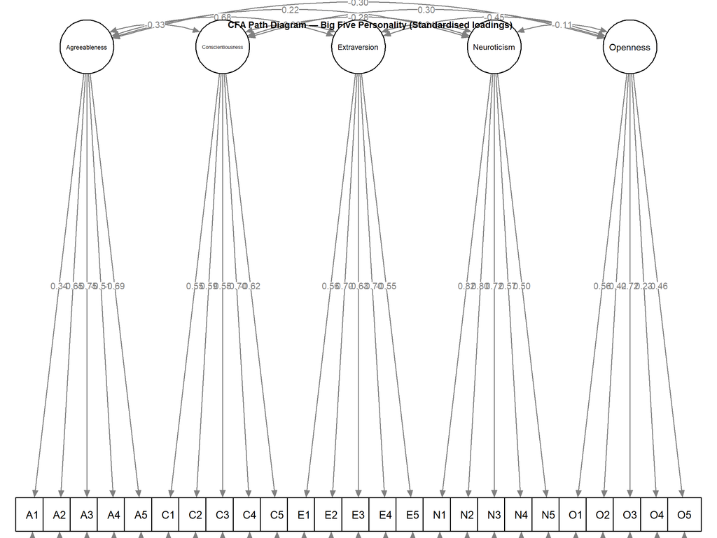

```r
semPaths(
  cfa_fit,
  whatLabels = "std",        # show standardised loadings on arrows
  layout     = "tree2",      # factors at top, items below
  style      = "lisrel",     # traditional box-and-arrow diagram
  edge.label.cex = 0.60,
  residuals  = TRUE,         # show residual variances as loops
  intercepts = FALSE,        # omit intercepts for cleanliness
  nCharNodes = 0,            # show full variable names (no truncation)
  mar        = c(1, 1, 2, 1)
)
title("CFA Path Diagram — Big Five Personality (Standardised loadings)", cex.main=0.9)
```

**Reading the path diagram:**

- **Ovals (or circles):** Latent variables (factors)
- **Rectangles (or squares):** Observed items
- **Single-headed arrows (→):** Factor loadings (from factor to item)
- **Numbers on arrows:** Standardised factor loadings
- **Small curved arrows (loops):** Residual variances — the variance in each item *not* explained by its factor
- **Double-headed arrows (↔︎) between ovals:** Factor correlations

# 6 Reliability Estimation

## 6.1 Cronbach’s Alpha — The Standard (But Imperfect) Coefficient

Cronbach’s alpha (α) estimates the proportion of scale variance attributable to the underlying construct. Values > .70 are conventionally “acceptable” for research; > .80 for applied settings; > .90 for clinical use.

**Alpha’s hidden assumption:** All items have *equal* factor loadings (tau-equivalence). When loadings are unequal — as they almost always are — alpha underestimates true reliability.

```r
# Compute alpha for the Extraversion subscale (E1–E5)
extra_items <- bfi_complete[, paste0("E", 1:5)]

alpha_res <- psych::alpha(extra_items)
```

```
## Some items ( E1 E2 ) were negatively correlated with the first principal component and
## probably should be reversed.
## To do this, run the function again with the 'check.keys=TRUE' option
```

```r
cat("=== Reliability Analysis: Extraversion (E1–E5) ===\n\n")
```

```
## === Reliability Analysis: Extraversion (E1–E5) ===
```

```r
cat("Cronbach's alpha (raw):     ", round(alpha_res$total$raw_alpha, 3), "\n")
```

```
## Cronbach's alpha (raw):      -0.655
```

```r
cat("Cronbach's alpha (std.):    ", round(alpha_res$total$std.alpha, 3), "\n")
```

```
## Cronbach's alpha (std.):     -0.531
```

```r
cat("Average inter-item r:       ", round(alpha_res$total$average_r, 3), "\n")
```

```
## Average inter-item r:        -0.075
```

```r
cat("Guttman's lambda 6 (G6):    ", round(alpha_res$total[["G6(smc)"]], 3), "\n")
```

```
## Guttman's lambda 6 (G6):     0.011
```

```r
cat("95% CI:                      [",
    round(alpha_res$total$raw_alpha - 1.96*alpha_res$total$ase, 3), ",",
    round(alpha_res$total$raw_alpha + 1.96*alpha_res$total$ase, 3), "]\n\n")
```

```
## 95% CI:                      [ -0.766 , -0.545 ]
```

```r
cat("Item-level statistics (what each item contributes):\n")
```

```
## Item-level statistics (what each item contributes):
```

```r
alpha_res$item.stats |>
  dplyr::select(r=r.cor, r.drop=r.drop) |>
  round(3) |>
  print()
```

```
##         r r.drop
## E1 -1.559 -0.269
## E2 -2.252 -0.369
## E3  1.909 -0.005
## E4  0.789 -0.208
## E5  1.307 -0.049
```

**Reading the alpha item statistics:**

- **r (item-total correlation):** How strongly each item correlates with the total scale score. Items with r < .30 are weakly related to the scale; consider dropping them.
- **r.drop (alpha if item dropped):** What alpha would be if this item were removed. If this value is *larger* than the overall alpha, the item is hurting reliability — it may be measuring something different.

## 6.2 McDonald’s Omega — The Better Coefficient

McDonald’s omega does not assume equal loadings. It uses the actual factor structure to estimate reliability. `omega_h` is the reliability attributable to the common factor; `omega_total` is the total reliability.

```r
omega_res <- omega(extra_items, nfactors=1,
                   title="Omega: Extraversion", plot=FALSE)

cat("=== McDonald's Omega: Extraversion ===\n\n")
```

```
## === McDonald's Omega: Extraversion ===
```

```r
cat("omega_h (hierarchical):  ", round(omega_res$omega_h, 3), "\n")
```

```
## omega_h (hierarchical):   0.767
```

```r
cat("omega_total:             ", round(omega_res$omega.tot, 3), "\n")
```

```
## omega_total:              0.768
```

```r
cat("Cronbach's alpha:        ", round(alpha_res$total$raw_alpha, 3), "\n\n")
```

```
## Cronbach's alpha:         -0.655
```

```r
cat("Interpretation:\n")
```

```
## Interpretation:
```

```r
cat("  omega_total and alpha are similar when loadings are equal (tau-equivalence holds)\n")
```

```
##   omega_total and alpha are similar when loadings are equal (tau-equivalence holds)
```

```r
cat("  omega_total > alpha when some items load higher than others (common situation)\n")
```

```
##   omega_total > alpha when some items load higher than others (common situation)
```

```r
cat("  omega_h is more conservative — it attributes only the common factor variance\n")
```

```
##   omega_h is more conservative — it attributes only the common factor variance
```

```r
cat("  Best practice: report both alpha (for comparability) and omega (for accuracy)\n")
```

```
##   Best practice: report both alpha (for comparability) and omega (for accuracy)
```

# 7 Checking Assumptions and Diagnosing Problems

## 7.1 Modification Indices

Modification indices (MIs) estimate how much chi-squared would drop if a specific parameter were freed. Large MIs suggest parts of the model that fit poorly.

```r
mi <- modindices(cfa_fit, sort.=TRUE, maximum.number=12)

mi |>
  filter(mi > 8) |>
  dplyr::select(lhs, op, rhs, mi, epc, sepc.all) |>
  mutate(
    mi       = round(mi, 2),
    epc      = round(epc, 3),
    sepc.all = round(sepc.all, 3),
    Type     = case_when(
      op == "=~" ~ "Cross-loading: item loads on additional factor",
      op == "~~" & lhs != rhs ~ "Residual correlation: items share specific variance",
      op == "~~" & lhs == rhs ~ "Free residual variance",
      TRUE ~ ""
    )
  ) |>
  kbl(caption="Modification Indices > 8 (Top Misspecifications)",
      col.names=c("LHS","Op","RHS","MI","EPC","Std.EPC","Type")) |>
  kable_styling(bootstrap_options=c("striped","hover","condensed")) |>
  footnote(general=paste(
    "MI = expected improvement in chi-squared if parameter is freed.",
    "EPC = expected parameter change (how large the new parameter would be).",
    "\nOnly add parameters with THEORETICAL justification.",
    "Never add parameters just because MI is large."
  ))
```

Modification Indices > 8 (Top Misspecifications)

| LHS | Op | RHS | MI | EPC | Std.EPC | Type |
| --- | --- | --- | --- | --- | --- | --- |
| N1 |  | N2 | 418.82 | 0.841 | 1.033 | Residual correlation: items share specific variance |
| Extraversion | =~ | N4 | 200.79 | 0.448 | 0.285 | Cross-loading: item loads on additional factor |
| Openness | =~ | E3 | 153.71 | 0.427 | 0.316 | Cross-loading: item loads on additional factor |
| N3 |  | N4 | 134.10 | 0.403 | 0.283 | Residual correlation: items share specific variance |
| Openness | =~ | E4 | 122.56 | -0.404 | -0.276 | Cross-loading: item loads on additional factor |
| Conscientiousness | =~ | E5 | 121.50 | 0.343 | 0.255 | Cross-loading: item loads on additional factor |
| Extraversion | =~ | O3 | 114.20 | -0.395 | -0.328 | Cross-loading: item loads on additional factor |
| Extraversion | =~ | O4 | 113.87 | 0.343 | 0.287 | Cross-loading: item loads on additional factor |
| Neuroticism | =~ | C5 | 108.75 | 0.352 | 0.216 | Cross-loading: item loads on additional factor |
| Extraversion | =~ | A5 | 108.59 | -0.449 | -0.354 | Cross-loading: item loads on additional factor |
| Neuroticism | =~ | C2 | 107.01 | 0.285 | 0.216 | Cross-loading: item loads on additional factor |
| C1 |  | C2 | 106.98 | 0.288 | 0.263 | Residual correlation: items share specific variance |

Note:  
MI = expected improvement in chi-squared if parameter is freed. EPC = expected parameter change (how large the new parameter would be). Only add parameters with THEORETICAL justification. Never add parameters just because MI is large.

**What to do with modification indices:**

1. Find the largest MI.
2. Ask: is there a *theoretical reason* why this parameter should exist?
3. If yes, add it to the model and refit. Note it in your methods as a “post-hoc modification.”
4. If no, do not add it. Large MI with no theoretical basis = capitalising on sample-specific noise.

The most common justified modification is a **residual correlation** between two items that share specific wording (e.g., both contain the word “feel”) or a specific subdimension beyond the common factor.